# Analisando dados abertos de viagens a serviço

## Objetivo

A proposta deste tópico é colocar em prática algumas das funções do R trabalhando com a análise de dados abertos de viagens a serviço, com o intuito de subsidiar a tomada de medidas mais eficientes na redução dos gastos com os custos dessas viagens no setor público.

## Definição do problema

Para resolver um problema, primeiramente temos que entendê-lo. Assim, precisamos entender os gastos com viagens a serviço para tomar medidas mais eficientes e, com isso, reduzir os custos dessas viagens.

## Questões relevantes

Qual é o valor gasto com passagens por órgão? Qual é o valor gasto com passagens por cidade? Qual é a quantidade de viagens por mês?

## Obtenção dos dados

Primeiramente vamos acessar o portal da transparencia do governo federal. disponivel em: http://www.portaltransparencia.gov.br/ Na aba dados do portal, iremos extrair os dados de Viagens realizadas a serviço, referente ao ano de 2019. Os dados extraidos estão no formato CSV.

## Carregando os dados

Acessando primeiramente a documentação da funcao que fará a leitura dos arquivos extraidos.

```r
?read.csv
```

Em seguida, aplicamos a função atribuindo a mesma em uma variavel chamada viagens.

```r
  viagens <- read.csv(file = "/Users/eraldomaia/Desktop/Enap/Análise de Dados em Linguagem R/Módulo 4 - Análise de Dados na Prática/AnaliseDeDadosViagensServico/Dados/Viagens-2019/2019_Viagem.csv", sep =';', dec = ',', fileEncoding = "latin1")
```

Agora verificamos se os dados foram carregados corretamente. Essa funcao head() apresenta apenas as primeiras linhas do DataSet.

```r
head(viagens)
```

|  | Identificador.do.processo.de.viagem | Número.da.Proposta..PCDP. | Situação | Viagem.Urgente | Justificativa.Urgência.Viagem | Código.do.órgão.superior | Nome.do.órgão.superior | Código.órgão.solicitante | Nome.órgão.solicitante | CPF.viajante | Nome | Cargo | Função | Descrição.Função | Período...Data.de.início | Período...Data.de.fim | Destinos | Motivo | Valor.diárias | Valor.passagens | Valor.outros.gastos |
| --- | --- | --- | --- | --- | --- | --- | --- | --- | --- | --- | --- | --- | --- | --- | --- | --- | --- | --- | --- | --- | --- |
| 1 | 15045825 | Sem informação | Realizada | NÃO | Sem informação | 26000 | Ministério da Educação | 26291 | Fundação Coordenação de Aperfeiçoamento de Pessoal de Nível Superior | ***.377.624-** | MARINA FERREIRA KITAZONO ANTUNES |  | -1 | Não Informado | 06/02/2019 | 07/02/2019 | Recife/PE | Regresso de bolsista CAPES do exterior- PE ( PROGRAMAS ESTRATÉGICOS -DRI ) | 0 | 3406.33 | 0 |
| 2 | 15100682 | Sem informação | Realizada | NÃO | Sem informação | 26000 | Ministério da Educação | 26291 | Fundação Coordenação de Aperfeiçoamento de Pessoal de Nível Superior | ***.831.975-** | JORGE ANDRE DE CARVALHO MENDONCA |  | -1 | Não Informado | 01/02/2019 | 02/02/2019 | Recife/PE | Capacitação PDSE (Programa de Doutorado Sanduíche no Exterior). | 0 | 2925.83 | 0 |
| 3 | 15114708 | Sem informação | Realizada | NÃO | Sem informação | 26000 | Ministério da Educação | 26291 | Fundação Coordenação de Aperfeiçoamento de Pessoal de Nível Superior | ***.325.718-** | MARCO ANTONIO COUTO JUNIOR | PESQUISADOR EM GEOCIENCIA | -1 | Não Informado | 01/02/2019 | 01/02/2019 | São Paulo/SP | Capacitação no exterior - PDSE | 0 | 2760.02 | 0 |
| 4 | 15163874 | Sem informação | Realizada | NÃO | Sem informação | 26000 | Ministério da Educação | 26291 | Fundação Coordenação de Aperfeiçoamento de Pessoal de Nível Superior | ***.003.005-** | OLIVAL FREIRE JUNIOR | PROFESSOR DO MAGISTERIO SUPERIOR | -1 | Não Informado | 17/02/2019 | 18/02/2019 | Salvador/BA | Programa de Professor Visitante no Exterior - PVEX | 0 | 2875.92 | 0 |
| 5 | 15166192 | Sem informação | Realizada | NÃO | Sem informação | 26000 | Ministério da Educação | 26291 | Fundação Coordenação de Aperfeiçoamento de Pessoal de Nível Superior | ***.660.311-** | CARINA MENDES DOS SANTOS MELO | TECNICO I | -1 | Não Informado | 20/02/2019 | 21/02/2019 | Rio de Janeiro/RJ | Capacitação no exterior - PDSE. | 0 | 2420.48 | 0 |
| 6 | 15188479 | Sem informação | Realizada | NÃO | Sem informação | 26000 | Ministério da Educação | 26291 | Fundação Coordenação de Aperfeiçoamento de Pessoal de Nível Superior | ***.655.130-** | RAFAEL RAMIRES JAQUES | PROFESSOR ENS BASICO TECN TECNOLOGICO | -1 | Não Informado | 06/03/2019 | 07/03/2019 | Porto Alegre/RS | Capacitação PDSE (Programa de Doutorado Sanduíche no Exterior). | 0 | 1262.50 | 0 |

Com isso, iremosveridicar as dimensões do DataSet (Linhas x Colunas).

```r
dim(viagens)
```

```
## [1] 838332     21
```

Em seguida iremos recuperar algumas informações do DataSet, como o valor minimo, maximo e a média, referente as viagens a serviço. Para isso, iremos utilizar a função summary().

Primeiramente, vamos acessar sua documentação.

```r
?summary
```

Em seguida, utilizamos a função no nosso DataSet.

```r
summary(viagens)
```

```
##  Identificador.do.processo.de.viagem Número.da.Proposta..PCDP.
##  Min.   :1.505e+07                   Length:838332
##  1st Qu.:1.602e+07                   Class :character
##  Median :1.629e+07                   Mode  :character
##  Mean   :2.099e+07
##  3rd Qu.:1.655e+07
##  Max.   :2.019e+09
##    Situação         Viagem.Urgente     Justificativa.Urgência.Viagem
##  Length:838332      Length:838332      Length:838332
##  Class :character   Class :character   Class :character
##  Mode  :character   Mode  :character   Mode  :character
##
##
##
##  Código.do.órgão.superior Nome.do.órgão.superior Código.órgão.solicitante
##  Min.   :   -1            Length:838332          Min.   :   -1
##  1st Qu.:25000            Class :character       1st Qu.:26000
##  Median :26000            Mode  :character       Median :26434
##  Mean   :30950                                   Mean   :30974
##  3rd Qu.:39000                                   3rd Qu.:37202
##  Max.   :63000                                   Max.   :91214
##  Nome.órgão.solicitante CPF.viajante           Nome
##  Length:838332          Length:838332      Length:838332
##  Class :character       Class :character   Class :character
##  Mode  :character       Mode  :character   Mode  :character
##
##
##
##     Cargo              Função          Descrição.Função
##  Length:838332      Length:838332      Length:838332
##  Class :character   Class :character   Class :character
##  Mode  :character   Mode  :character   Mode  :character
##
##
##
##  Período...Data.de.início Período...Data.de.fim   Destinos
##  Length:838332            Length:838332         Length:838332
##  Class :character         Class :character      Class :character
##  Mode  :character         Mode  :character      Mode  :character
##
##
##
##     Motivo          Valor.diárias      Valor.passagens    Valor.outros.gastos
##  Length:838332      Min.   :     0.0   Min.   :     0.0   Min.   :    0.00
##  Class :character   1st Qu.:    88.5   1st Qu.:     0.0   1st Qu.:    0.00
##  Mode  :character   Median :   431.3   Median :     0.0   Median :    0.00
##                     Mean   :   953.3   Mean   :   590.4   Mean   :   21.51
##                     3rd Qu.:   817.2   3rd Qu.:   894.6   3rd Qu.:    0.00
##                     Max.   :104793.1   Max.   :155531.4   Max.   :29546.00
```

```r
summary(viagens$Valor.passagens)
```

```
##     Min.  1st Qu.   Median     Mean  3rd Qu.     Max.
##      0.0      0.0      0.0    590.4    894.6 155531.4
```

Agora, iremos verificar o tipo dos dados de cada coluna. Para isso, iremos instalar o pacote “dplyr”

```r
 #install.packages("dplyr")
```

Em seguida carregamos o pacote instalado.

```r
library(dplyr)
```

Com o pacote “dplyr” carregado. Iremos utilizar a funcao “glimpse” para verificar o tipo dos dados de cada coluna.

```r
glimpse(viagens)
```

```
## Rows: 838,332
## Columns: 21
## $ Identificador.do.processo.de.viagem <int> 15045825, 15100682, 15114708, 151…
## $ Número.da.Proposta..PCDP.           <chr> "Sem informação", "Sem informação…
## $ Situação                            <chr> "Realizada", "Realizada", "Realiz…
## $ Viagem.Urgente                      <chr> "NÃO", "NÃO", "NÃO", "NÃO", "NÃO"…
## $ Justificativa.Urgência.Viagem       <chr> "Sem informação", "Sem informação…
## $ Código.do.órgão.superior            <int> 26000, 26000, 26000, 26000, 26000…
## $ Nome.do.órgão.superior              <chr> "Ministério da Educação", "Minist…
## $ Código.órgão.solicitante            <int> 26291, 26291, 26291, 26291, 26291…
## $ Nome.órgão.solicitante              <chr> "Fundação Coordenação de Aperfeiç…
## $ CPF.viajante                        <chr> "***.377.624-**", "***.831.975-**…
## $ Nome                                <chr> "MARINA FERREIRA KITAZONO ANTUNES…
## $ Cargo                               <chr> "", "", "PESQUISADOR EM GEOCIENCI…
## $ Função                              <chr> "-1", "-1", "-1", "-1", "-1", "-1…
## $ Descrição.Função                    <chr> "Não Informado", "Não Informado",…
## $ Período...Data.de.início            <chr> "06/02/2019", "01/02/2019", "01/0…
## $ Período...Data.de.fim               <chr> "07/02/2019", "02/02/2019", "01/0…
## $ Destinos                            <chr> "Recife/PE", "Recife/PE", "São Pa…
## $ Motivo                              <chr> "Regresso de bolsista CAPES do ex…
## $ Valor.diárias                       <dbl> 0.00, 0.00, 0.00, 0.00, 0.00, 0.0…
## $ Valor.passagens                     <dbl> 3406.33, 2925.83, 2760.02, 2875.9…
## $ Valor.outros.gastos                 <dbl> 0, 0, 0, 0, 0, 0, 0, 0, 0, 0, 0, …
```

## Tratando os dados obtidos

Como podemos ver acima, as colunas “Período…Data.de.início” e “Período…Data.de.fim” estão como tipo “chr”. Nesse caso, será necessário transforma-las par tipo data.

Primeiramente, vamos acessar sua documentação.

```r
?as.Date
```

Em seguida, atribuimos a função na coluna “Período…Data.de.início” , para criar uma nova coluna, data.inicio com o tipo Data.

```r
viagens$data.inicio <- as.Date(viagens$Período...Data.de.início,"%d/%m/%Y")
```

A coluna original não foi alterada, apenas a nova “data.inicio”.

Como podemos verificar abaixo.

```r
glimpse(viagens)
```

```
## Rows: 838,332
## Columns: 22
## $ Identificador.do.processo.de.viagem <int> 15045825, 15100682, 15114708, 151…
## $ Número.da.Proposta..PCDP.           <chr> "Sem informação", "Sem informação…
## $ Situação                            <chr> "Realizada", "Realizada", "Realiz…
## $ Viagem.Urgente                      <chr> "NÃO", "NÃO", "NÃO", "NÃO", "NÃO"…
## $ Justificativa.Urgência.Viagem       <chr> "Sem informação", "Sem informação…
## $ Código.do.órgão.superior            <int> 26000, 26000, 26000, 26000, 26000…
## $ Nome.do.órgão.superior              <chr> "Ministério da Educação", "Minist…
## $ Código.órgão.solicitante            <int> 26291, 26291, 26291, 26291, 26291…
## $ Nome.órgão.solicitante              <chr> "Fundação Coordenação de Aperfeiç…
## $ CPF.viajante                        <chr> "***.377.624-**", "***.831.975-**…
## $ Nome                                <chr> "MARINA FERREIRA KITAZONO ANTUNES…
## $ Cargo                               <chr> "", "", "PESQUISADOR EM GEOCIENCI…
## $ Função                              <chr> "-1", "-1", "-1", "-1", "-1", "-1…
## $ Descrição.Função                    <chr> "Não Informado", "Não Informado",…
## $ Período...Data.de.início            <chr> "06/02/2019", "01/02/2019", "01/0…
## $ Período...Data.de.fim               <chr> "07/02/2019", "02/02/2019", "01/0…
## $ Destinos                            <chr> "Recife/PE", "Recife/PE", "São Pa…
## $ Motivo                              <chr> "Regresso de bolsista CAPES do ex…
## $ Valor.diárias                       <dbl> 0.00, 0.00, 0.00, 0.00, 0.00, 0.0…
## $ Valor.passagens                     <dbl> 3406.33, 2925.83, 2760.02, 2875.9…
## $ Valor.outros.gastos                 <dbl> 0, 0, 0, 0, 0, 0, 0, 0, 0, 0, 0, …
## $ data.inicio                         <date> 2019-02-06, 2019-02-01, 2019-02-…
```

Agora formatamos o campo “data.inicio”, para trabalhar apenas com o mes e o ano.

Utilizando a função “format()”

Primeiramente, vamos acessar sua documentação.

```r
?format
```

Em seguida formatamos o campo “data.inicio”, criando um novo campo “data.inicio.mes.ano”

```r
viagens$data.inicio.mes.ano <- format(viagens$data.inicio,"%m-%y")
```

Verificando as alterações

```r
glimpse(viagens)
```

```
## Rows: 838,332
## Columns: 23
## $ Identificador.do.processo.de.viagem <int> 15045825, 15100682, 15114708, 151…
## $ Número.da.Proposta..PCDP.           <chr> "Sem informação", "Sem informação…
## $ Situação                            <chr> "Realizada", "Realizada", "Realiz…
## $ Viagem.Urgente                      <chr> "NÃO", "NÃO", "NÃO", "NÃO", "NÃO"…
## $ Justificativa.Urgência.Viagem       <chr> "Sem informação", "Sem informação…
## $ Código.do.órgão.superior            <int> 26000, 26000, 26000, 26000, 26000…
## $ Nome.do.órgão.superior              <chr> "Ministério da Educação", "Minist…
## $ Código.órgão.solicitante            <int> 26291, 26291, 26291, 26291, 26291…
## $ Nome.órgão.solicitante              <chr> "Fundação Coordenação de Aperfeiç…
## $ CPF.viajante                        <chr> "***.377.624-**", "***.831.975-**…
## $ Nome                                <chr> "MARINA FERREIRA KITAZONO ANTUNES…
## $ Cargo                               <chr> "", "", "PESQUISADOR EM GEOCIENCI…
## $ Função                              <chr> "-1", "-1", "-1", "-1", "-1", "-1…
## $ Descrição.Função                    <chr> "Não Informado", "Não Informado",…
## $ Período...Data.de.início            <chr> "06/02/2019", "01/02/2019", "01/0…
## $ Período...Data.de.fim               <chr> "07/02/2019", "02/02/2019", "01/0…
## $ Destinos                            <chr> "Recife/PE", "Recife/PE", "São Pa…
## $ Motivo                              <chr> "Regresso de bolsista CAPES do ex…
## $ Valor.diárias                       <dbl> 0.00, 0.00, 0.00, 0.00, 0.00, 0.0…
## $ Valor.passagens                     <dbl> 3406.33, 2925.83, 2760.02, 2875.9…
## $ Valor.outros.gastos                 <dbl> 0, 0, 0, 0, 0, 0, 0, 0, 0, 0, 0, …
## $ data.inicio                         <date> 2019-02-06, 2019-02-01, 2019-02-…
## $ data.inicio.mes.ano                 <chr> "02-19", "02-19", "02-19", "02-19…
```

## Analise exploratória dos dados

Como iremos trbalhar na descobeta de custos com passagens, iremos fazer uma analise em cima dos dados referente ao valor da passagem.

```r
summary(viagens$Valor.passagens)
```

```
##     Min.  1st Qu.   Median     Mean  3rd Qu.     Max.
##      0.0      0.0      0.0    590.4    894.6 155531.4
```

É possivel perceber que o valor maximo está bem distante da média, o que indica a presença de outliers. Que podem o resultado de uma analise que não reflita a realidade.

Sendo melhor visualizado em um grafico. Nesse caso utilizaremos um grafico boxsplot.

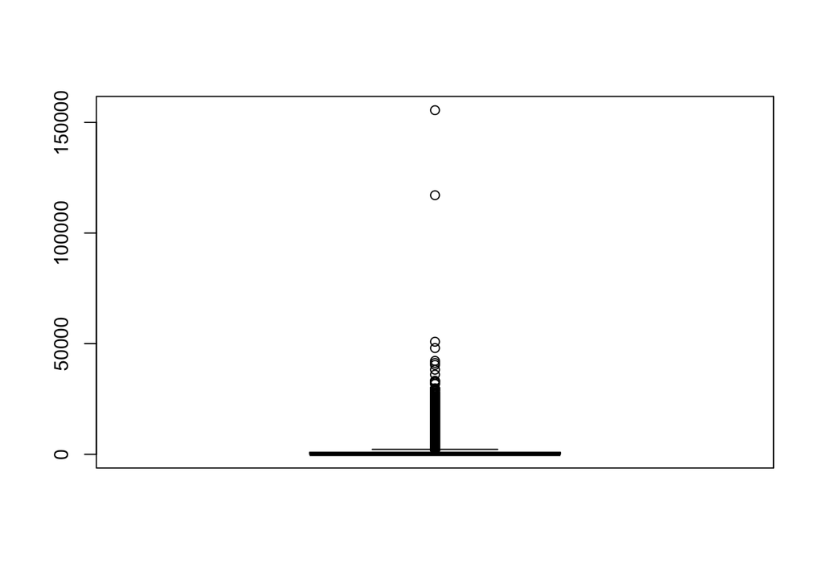

```r
boxplot(viagens$Valor.passagens)
```

Além disso, iremos calcular o desvio padrao.

Utilizando a função “sd()”

Primeiramente, vamos acessar sua documentação.

```r
?sd
```

Em seguida calculamos o desvio padrao da coluna “Valor.passagens”

```r
sd(viagens$Valor.passagens)
```

```
## [1] 1286.866
```

Em seguida, vamos verificar se existem campos com valores não preechidos e contabilizar sua quantidade.

Utilizando a função “is.na()” e a função “colSums()”

Primeiramente, vamos acessar sua documentação.

```r
?is.na
?colSums
```

Agora verificamos se existem campos com valores não preechidos e contabilizar sua quantidade.

```r
colSums(is.na(viagens))
```

```
## Identificador.do.processo.de.viagem           Número.da.Proposta..PCDP.
##                                   0                                   0
##                            Situação                      Viagem.Urgente
##                                   0                                   0
##       Justificativa.Urgência.Viagem            Código.do.órgão.superior
##                                   0                                   0
##              Nome.do.órgão.superior            Código.órgão.solicitante
##                                   0                                   0
##              Nome.órgão.solicitante                        CPF.viajante
##                                   0                                   0
##                                Nome                               Cargo
##                                   0                                   0
##                              Função                    Descrição.Função
##                                   0                                   0
##            Período...Data.de.início               Período...Data.de.fim
##                                   0                                   0
##                            Destinos                              Motivo
##                                   0                                   0
##                       Valor.diárias                     Valor.passagens
##                                   0                                   0
##                 Valor.outros.gastos                         data.inicio
##                                   0                                   0
##                 data.inicio.mes.ano
##                                   0
```

Como podemos ver cima, não existem campos que não foram preenchidos!

É interessante, a verificação da situação de cada viagem.

```r
table(viagens$Situação)
```

```
##
## Não realizada     Realizada
##         19076        819256
```

E a relação entre as viagens que foram realizadas e não realizadas

```r
sit <- prop.table(table(viagens$Situação))*100

sit
```

```
##
## Não realizada     Realizada
##      2.275471     97.724529
```

Temos que cerca de 97.7% das viagens pagas, foram realizadas.

Vamos vizualizar em um grafico de pizza.

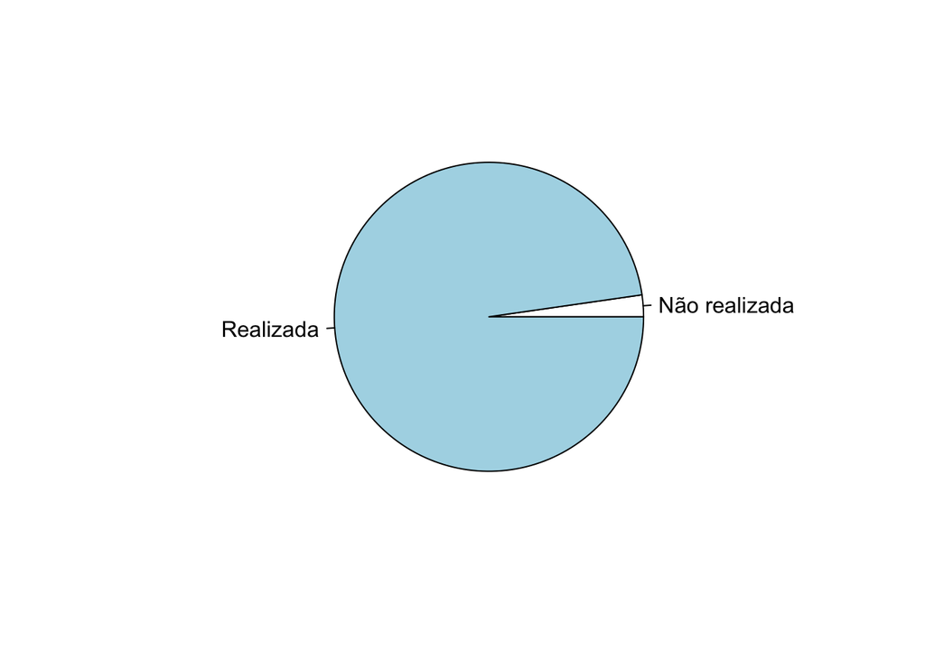

```r
?pie
pie(sit)
```

## Visualização dos resultados

A visualização dos resultados é a etapa final do nosso estudo acerca da análise dos dados de viagens a serviço. Assim, é o momento de responder às questões levantadas na primeira fase: definição do problema. Vamos relembrá-las?

Qual é o valor gasto com passagens por órgão? Qual é o valor gasto com passagens por cidade? Qual é a quantidade de viagens por mês?

Primeiramente iremos descobrir quais orgãos estão gastando mais com passagens aereas. Para isso iremos criar um “top 10” com os orgãos que estão gastando mais.

```r
p1 <- viagens %>% group_by(Nome.do.órgão.superior) %>% summarise(n = sum(Valor.passagens), .groups = 'drop') %>% arrange(desc(n)) %>% top_n(10)
names(p1) <- c("Orgão","Valor")

p1
```

| Orgão | Valor |
| --- | --- |
| Ministério da Educação | 110895519 |
| Ministério da Defesa | 83855844 |
| Sem informação | 54809571 |
| Ministério da Justiça e Segurança Pública | 47641692 |
| Ministério da Saúde | 34271541 |
| Ministério da Economia | 28132104 |
| Ministério das Relações Exteriores | 20379258 |
| Ministério da Infraestrutura | 18872923 |
| Ministério da Ciência, Tecnologia, Inovações e Comunicações | 16431832 |
| Ministério do Meio Ambiente | 16375960 |

Apos a consolidação dos dados, iremos plota-los em grafico.

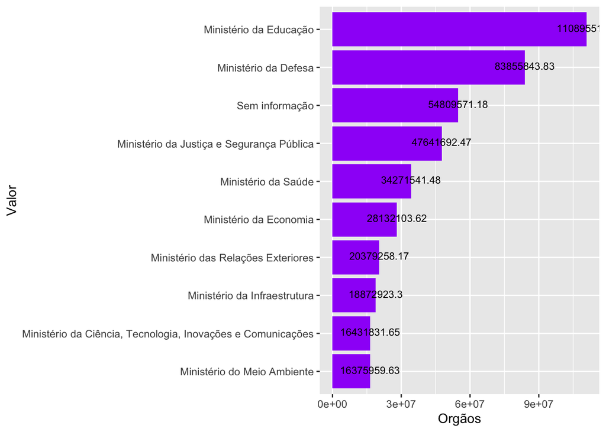

```r
library(ggplot2)
ggplot(p1,aes(x=reorder(Orgão,Valor),y=Valor)) + geom_bar(stat = "identity", fill = "#9F1BF7") + geom_text(aes(label = Valor), vjust = 0.3, size = 3) + coord_flip() + labs(x="Valor",y= "Orgãos")
```

Agora iremos descobrir quais cidades estão gastando mais com passagens aereas. Para isso iremos criar um “top 10” com as cidades que estão gastando mais.

```r
p2 <- viagens %>% group_by(Destinos) %>% summarise(n = sum(Valor.passagens), .groups = 'drop') %>% arrange(desc(n)) %>% top_n(10)
names(p2) <- c("Destino","Valor")

p2
```

| Destino | Valor |
| --- | --- |
| Brasília/DF | 95862548 |
| Informações protegidas por sigilo | 51184144 |
| Rio de Janeiro/RJ | 32904374 |
| São Paulo/SP | 28182692 |
| Sem informação | 23885737 |
| Manaus/AM | 10018771 |
| Recife/PE | 7792972 |
| Curitiba/PR | 7231037 |
| Belo Horizonte/MG | 7215254 |
| Porto Alegre/RS | 6746214 |

Após a consolidação dos dados, iremos plota-los em grafico.

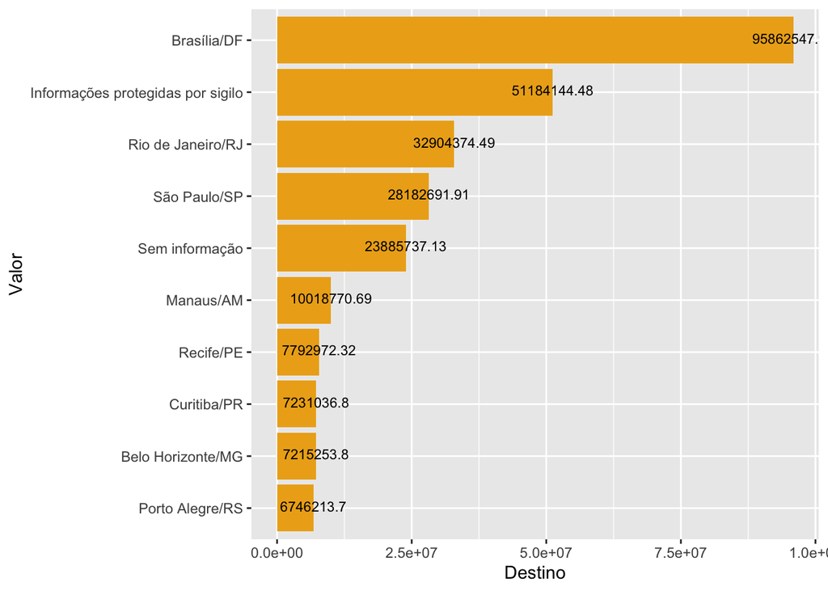

```r
ggplot(p2,aes(x=reorder(Destino,Valor),y=Valor)) + geom_bar(stat = "identity", fill = "#EDAD1A") + geom_text(aes(label = Valor), vjust = 0.3, size = 3) + coord_flip() + labs(x="Valor",y= "Destino")
```

Agora iremos desobrir a quantidade de viagens realizadas por mês.

```r
p3 <-  viagens %>% group_by(data.inicio.mes.ano) %>% summarise(qtd = n_distinct(Identificador.do.processo.de.viagem), .groups = 'drop')

p3
```

| data.inicio.mes.ano | qtd |
| --- | --- |
| 01-19 | 30930 |
| 02-19 | 55837 |
| 03-19 | 64909 |
| 04-19 | 70413 |
| 05-19 | 79406 |
| 06-19 | 73021 |
| 07-19 | 65682 |
| 08-19 | 81322 |
| 09-19 | 81545 |
| 10-19 | 80251 |

[output cut: 2 more lines]

Após a consolidação dos dados, iremos plota-los em grafico.

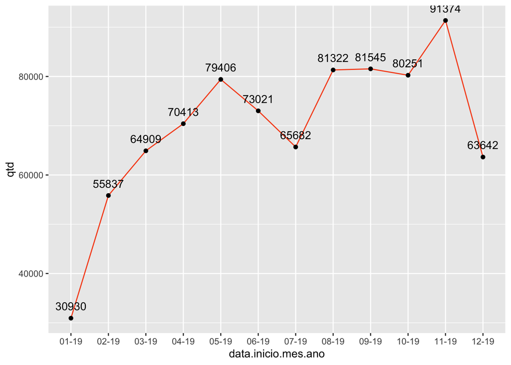

```r
ggplot(p3, aes(x = data.inicio.mes.ano, y = qtd, group = 1)) + geom_line(colour = "#F74F1B") + geom_point() + geom_text(vjust = -1,aes(label = qtd))
```